# Viz and Share

# The data cleaned and in the right format?

As soon as you opena data file, you must check the data types with **str()**:

```r
rm(list = ls())

###
git='https://github.com/DACSS-Fundamentals/'
org='vizandshare/raw/main/'
file='ciadata.rds'
gitLocation=paste0(git,org)
fullLocation=paste0(gitLocation,file)
cia=readRDS(url(fullLocation))

##
str(cia)
```

```
## 'data.frame':    147 obs. of  6 variables:
##  $ name    : chr  "Albania" "Angola" "Argentina" "Armenia" ...
##  $ maternal: int  7 183 33 19 2 6 115 35 1 4 ...
##  $ infant  : num  10.3 55.6 9 11.6 2.9 3.2 28.8 9.6 2.1 3.1 ...
##  $ life_exp: num  79.9 62.9 78.8 76.7 83.5 82.7 75.2 79 74.7 82.3 ...
##  $ gini    : num  29.4 51.3 42.4 27.2 34.3 30.9 33.4 34.1 24.4 26.4 ...
##  $ region  : Factor w/ 10 levels "Africa","Australia and Oceania",..: 6 1 9 4 2 6 10 3 6 6 ...
```

# You may have several variables…but

You just do not open a data file for a random reason. You have a purpose.

## Which is your variable of interest?

- Life Expectancy

## Which are you considering as explanatory variables?

- Infant mortality rate
- Maternal mortality rate

## Any Control Variable?

- GINI index
- Region

# Exploration

Do not plan any advanced work if you have not explored the set of columns you need.

## Univariate : Your variable of interest

### key stats

```r
summary(cia$life_exp)
```

```
##    Min. 1st Qu.  Median    Mean 3rd Qu.    Max.
##   56.40   70.10   75.20   74.06   78.85   86.70
```

The above may be supplemented by:

```r
library(moments)
skewness(cia$life_exp)
```

```
## [1] -0.4950852
```

The tail is to the left (would be to the right if positive)

### Visual

How to highlight the stats above?

```r
# call the library
library(ggplot2) # do not expect an important message
```

```r
# tell ggplot the data you will use
base=ggplot(data=cia) # I call it 'base'
```

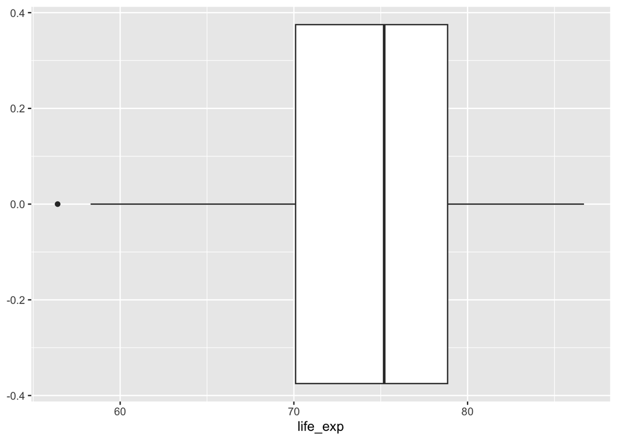

```r
# add the desired 'geom'
base + geom_boxplot( # you want a boxplot
                    aes(x=life_exp) # aes for the 'vars'
                    )
```

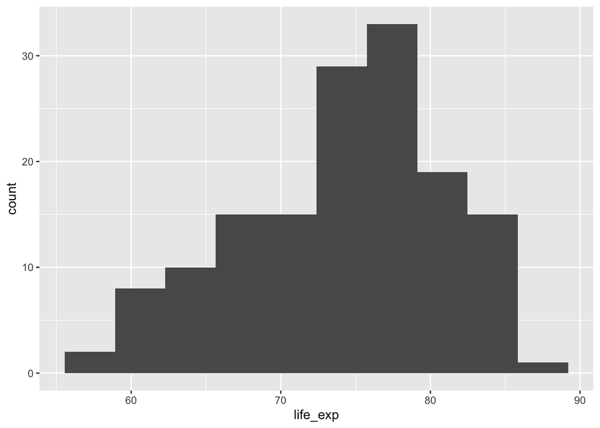

```r
# this is another alternative
base + geom_histogram(aes(x=life_exp),bins = 10)
```

Let’s choose the boxplot and add some **textual** decorations:

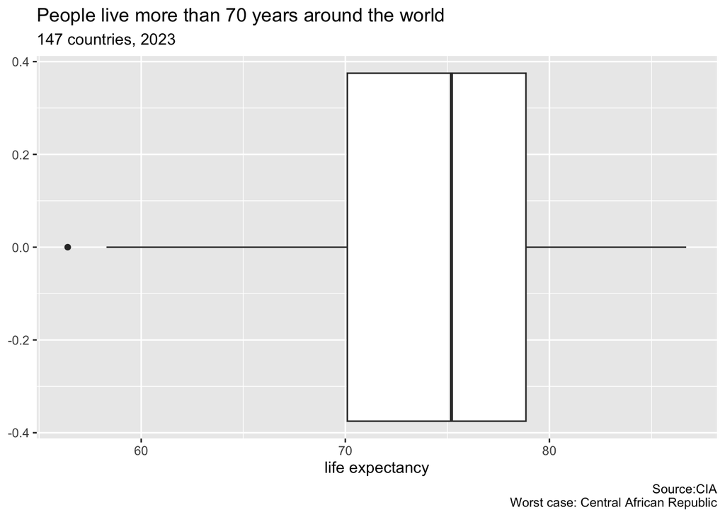

```r
# detecting the worst case
worstCase=cia[which.min(cia$life_exp),'name']
# preparing a message
theCaption=paste("Source:CIA\n","Worst case:",worstCase)

# text for titles
theTitle='People live more than 70 years around the world'
theSubtitle="147 countries, 2023"

# time te REPLOT
box=base + geom_boxplot(aes(x=life_exp))
box + labs(title=theTitle,
           subtitle = theSubtitle,
           caption = theCaption,
           x= 'life expectancy')
```

## Bivariate

### Key stats

- what about a correlation

```r
corrtable::correlation_matrix(df = cia[,-c(1,5,6)],
                              use = 'lower',
                              replace_diagonal = T)
```

```
##          maternal    infant      life_exp
## maternal ""          ""          ""
## infant   " 0.803***" ""          ""
## life_exp "-0.755***" "-0.905***" ""
```

### Visuals

- Visualizing the correlation

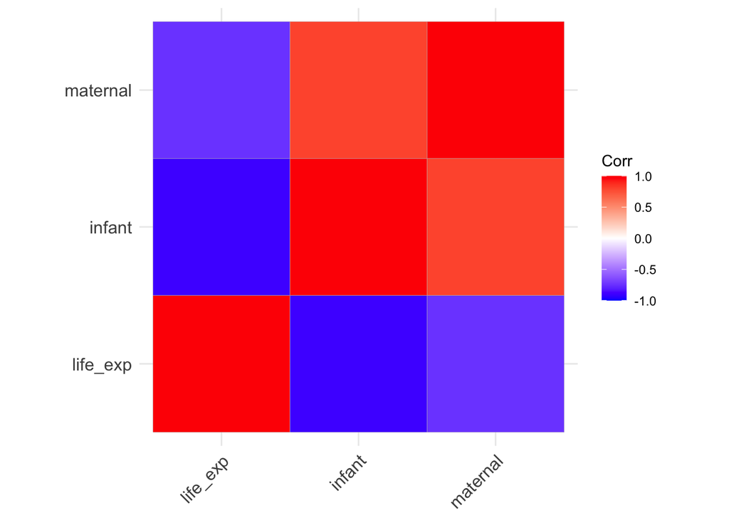

```r
library(ggcorrplot) # may need installation

# 1. Compute the correlation matrix
corr_matrix <- cor(cia[, c('life_exp',"infant", "maternal")])

# 2. Plot
ggcorrplot(corr_matrix)
```

# Time to test your Hypothesis!

## Key stats

Prepare you hypothesis:

```r
# the H
hypo=formula(life_exp ~ infant + maternal + gini)
```

Test your hypothesis and see the outcome:

```r
model <- lm(hypo, data = cia)

#then
summary(model)
```

```
##
## Call:
## lm(formula = hypo, data = cia)
##
## Residuals:
##     Min      1Q  Median      3Q     Max
## -8.1922 -1.4455 -0.1265  1.9600  7.4221
##
## Coefficients:
##              Estimate Std. Error t value Pr(>|t|)
## (Intercept) 83.360341   1.218011  68.440   <2e-16 ***
## infant      -0.298612   0.021945 -13.607   <2e-16 ***
## maternal    -0.003325   0.002281  -1.458   0.1471
## gini        -0.078920   0.034403  -2.294   0.0232 *
## ---
## Signif. codes:  0 '***' 0.001 '**' 0.01 '*' 0.05 '.' 0.1 ' ' 1
##
## Residual standard error: 2.861 on 143 degrees of freedom
## Multiple R-squared:  0.8274, Adjusted R-squared:  0.8237
## F-statistic: 228.4 on 3 and 143 DF,  p-value: < 2.2e-16
```

** Above, you just found some important difference between correlation and regression.**

## Visual

Regression coefficients are easy to plot:

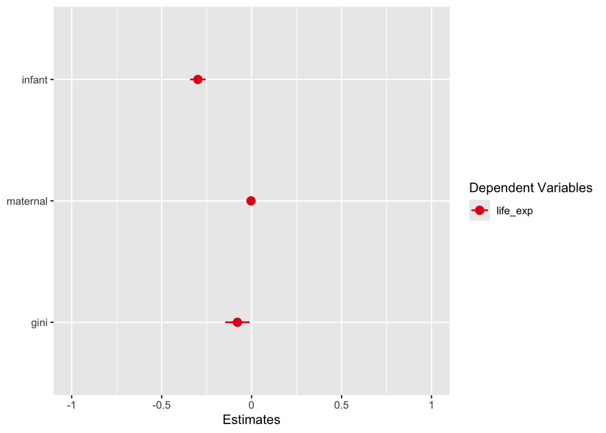

```r
library(sjPlot)
plot_models(model)
```

# Playing with simple commands and find some insight?

If this is the data:

```r
head(cia)
```

|  | name | maternal | infant | life_exp | gini | region |
| --- | --- | --- | --- | --- | --- | --- |
| 1 | Albania | 7 | 10.3 | 79.9 | 29.4 | Europe |
| 2 | Angola | 183 | 55.6 | 62.9 | 51.3 | Africa |
| 3 | Argentina | 33 | 9.0 | 78.8 | 42.4 | South America |
| 4 | Armenia | 19 | 11.6 | 76.7 | 27.2 | Central Asia |
| 5 | Australia | 2 | 2.9 | 83.5 | 34.3 | Australia and Oceania |
| 6 | Austria | 6 | 3.2 | 82.7 | 30.9 | Europe |

You can make it ‘talk’ using basic operations.

## Life expectancy by region?

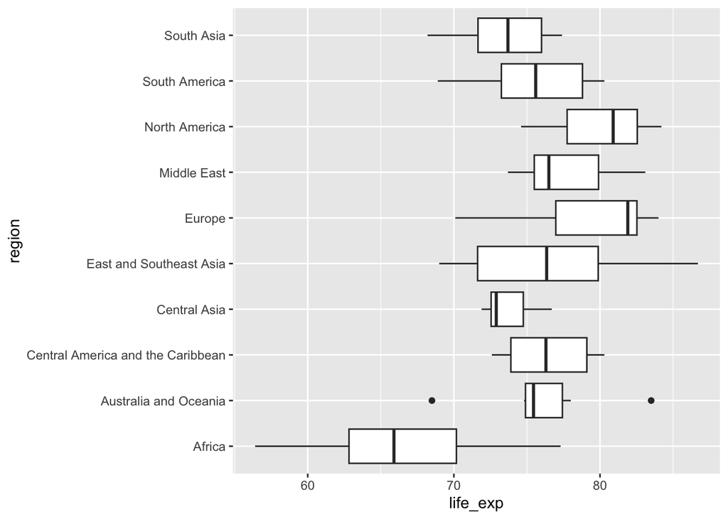

```r
# version 1
base + geom_boxplot(aes(x=life_exp,y=region))
```

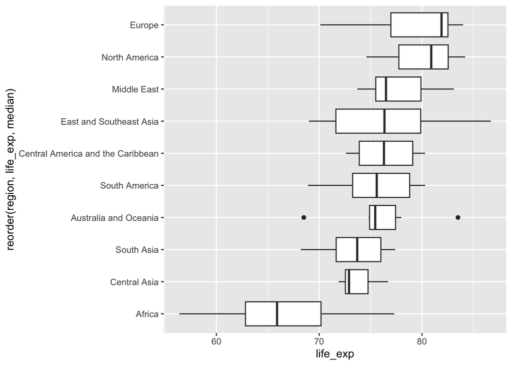

```r
# version 2
base + geom_boxplot(aes(x=life_exp,y=reorder(region,life_exp,median)))
```

Which of the above gave you something else to state?

## A box plot for each var?

Remember this is not right:

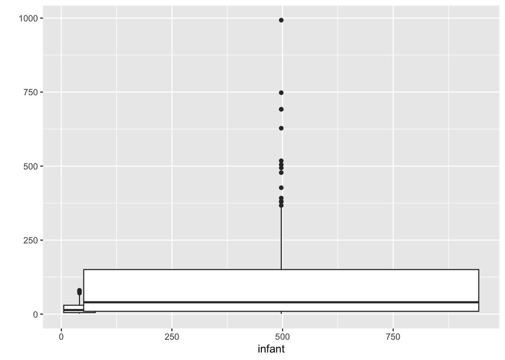

```r
base+geom_boxplot(aes(x=infant,y=infant)) +
     geom_boxplot(aes(x=maternal,y=maternal)) + labs(y='')
```

We need a long shape for **ggplot2**:

```r
ciaLong=tidyr::pivot_longer(data=cia[,c(1,2,3,4)],
                                cols=!name,
                                names_to = "vars",
                                values_to = "index")
ciaLong
```

| name | vars | index |
| --- | --- | --- |
| Albania | maternal | 7.0 |
| Albania | infant | 10.3 |
| Albania | life_exp | 79.9 |
| Angola | maternal | 183.0 |
| Angola | infant | 55.6 |
| Angola | life_exp | 62.9 |
| Argentina | maternal | 33.0 |
| Argentina | infant | 9.0 |
| Argentina | life_exp | 78.8 |
| Armenia | maternal | 19.0 |

[output cut: 431 more lines]

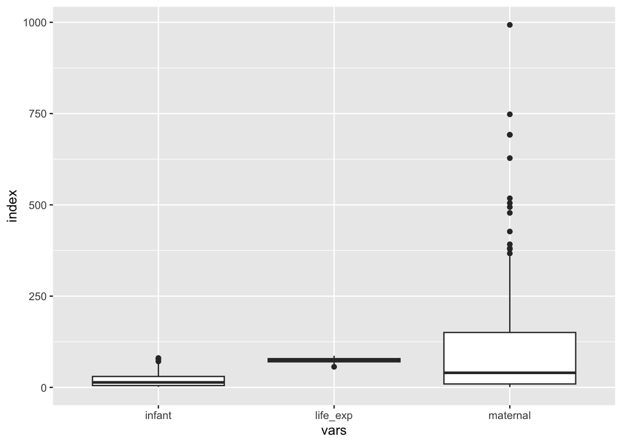

```r
# then
base = ggplot(data=ciaLong)
base + geom_boxplot(aes(x=vars,y=index))
```

Good data, but visually still weak. What happened? Each variable has different range (min - max). Then:

**Faceting**

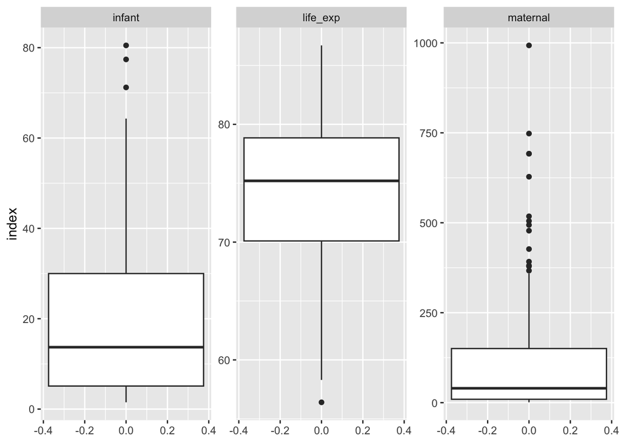

```r
base2 = ggplot(data=ciaLong)
base2 + geom_boxplot(aes(y=index)) +
  facet_wrap(~ vars, scales = "free")
```

Facetting is very useful:

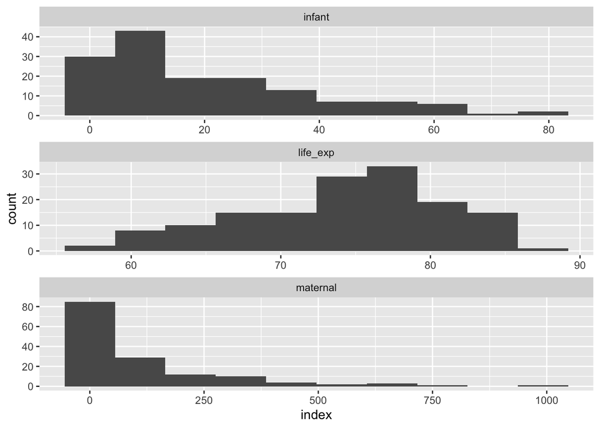

```r
base2 = ggplot(data=ciaLong)
base2 + geom_histogram(aes(x=index),bins=10) +
  facet_wrap(vars~., scales = "free", ncol = 1)
```

## Mortality worst group?

We can detect countries in worst groups.

```r
# Find the value that marks the top 25% (worst)
inf_bad <- quantile(cia$infant, 0.75, na.rm = TRUE)
mat_bad   <- quantile(cia$maternal, 0.75, na.rm = TRUE)

# '1' if in the worst quartile:
cia$inf_worst <- ifelse(cia$infant >= inf_bad, 1, 0)
cia$mat_worst   <- ifelse(cia$maternal >= mat_bad, 1, 0)

# flag worst of worst
cia$worst_infmat=cia$inf_worst + cia$mat_worst

cia$worst_infmat=ifelse(cia$worst_infmat==2,T,F)
```

Report:

```r
aggregate(worst_infmat ~ region, data = cia, FUN = sum, na.rm = TRUE)
```

| region | worst_infmat |
| --- | --- |
| Africa | 28 |
| Australia and Oceania | 0 |
| Central America and the Caribbean | 0 |
| Central Asia | 0 |
| East and Southeast Asia | 1 |
| Europe | 0 |
| Middle East | 0 |
| North America | 0 |
| South America | 0 |
| South Asia | 1 |

## Mortality best group?

```r
inf_good <- quantile(cia$infant, 0.25, na.rm = TRUE)
mat_good   <- quantile(cia$maternal, 0.25, na.rm = TRUE)

# NOW 'less than'
cia$inf_best <- ifelse(cia$infant <= inf_good, 1, 0)
cia$mat_best   <- ifelse(cia$maternal <= mat_good, 1, 0)

# flag worst of worst
cia$best_infmat=cia$inf_best + cia$mat_best

cia$best_infmat=ifelse(cia$best_infmat==2,T,F)
```

Report:

```r
aggregate(best_infmat ~ region, data = cia, FUN = sum, na.rm = TRUE)
```

| region | best_infmat |
| --- | --- |
| Africa | 0 |
| Australia and Oceania | 1 |
| Central America and the Caribbean | 0 |
| Central Asia | 0 |
| East and Southeast Asia | 3 |
| Europe | 25 |
| Middle East | 2 |
| North America | 0 |
| South America | 0 |
| South Asia | 0 |

Plotting!

[output not shown]

and….

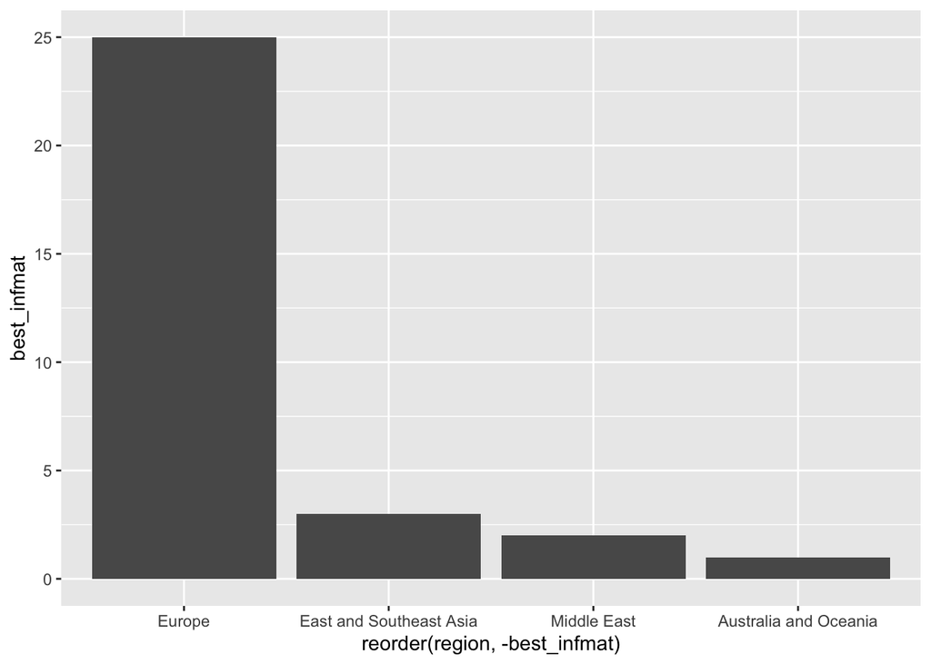

```r
# saving as object
counts_best <- aggregate(best_infmat ~ region, data = cia, FUN = sum)
# filtering
counts_best=counts_best[counts_best$best_infmat>0,]

# plotting
base_best=ggplot(data=counts_best)

base_best + geom_col(aes(x = reorder(region, -best_infmat),
                       y = best_infmat))
```